# Skelly 10x heart

Lihui Lin

August 2, 2018

# Clustering heart data

The single cell were sorted from male and female mouse at 10 weeks old. The cardiac cells and a portion of endothelial cells were filter out.

## Look through the data

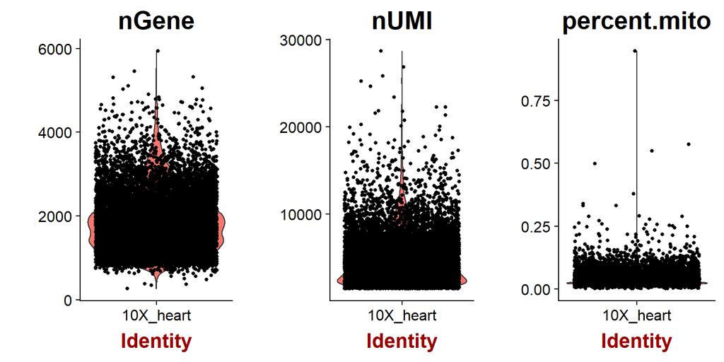

## Seurat clustering

The cells were clustering using [Seurat,2016](https://satijalab.org/seurat/get_started.html). The top 8 PCs were used as imput. No mitochondrion genes were detected as HVG.

Determine statistically significant principal components. We select top 8 pcs for clustering.

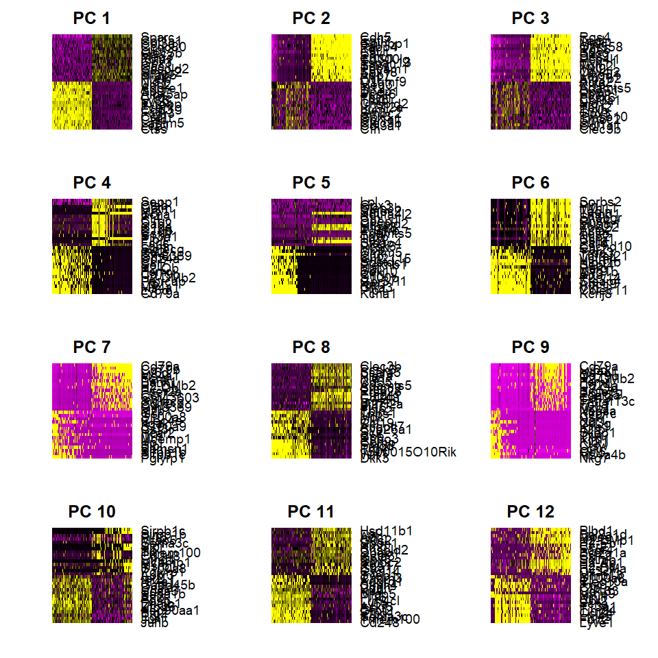

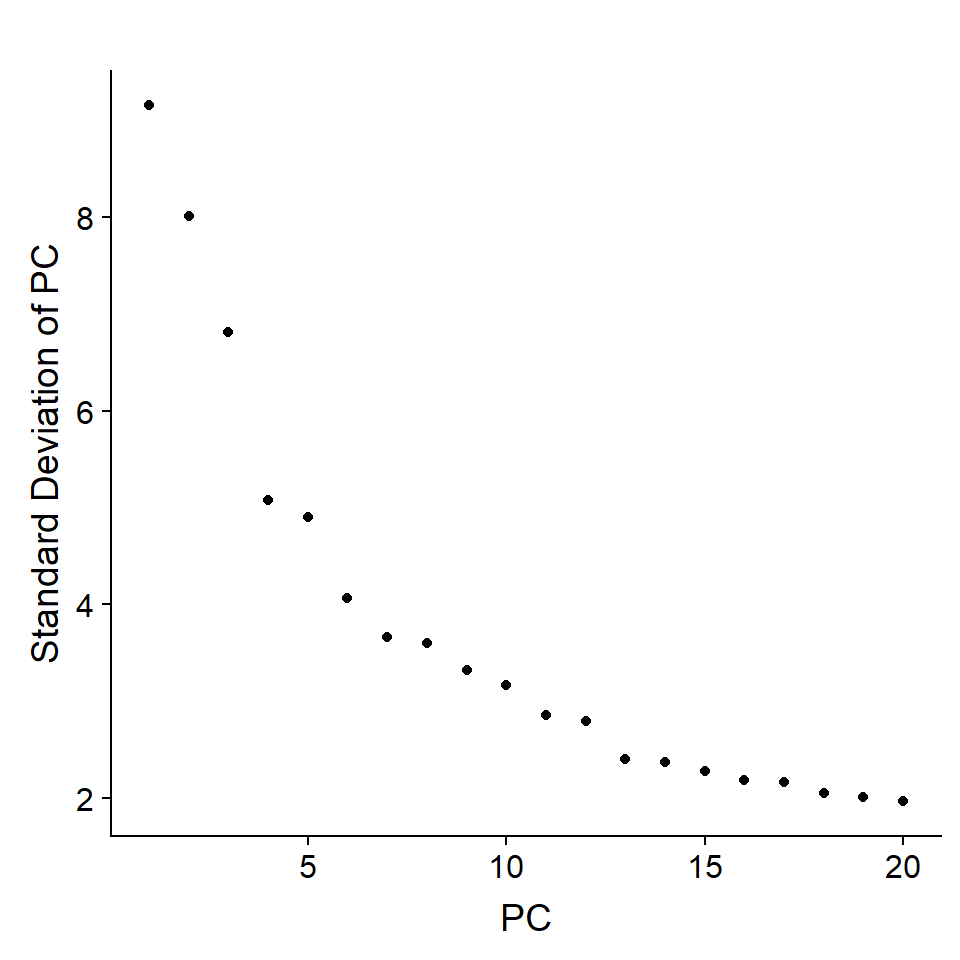

tSNE and UMAP are two non-linear dimention reduction algorithm. The clustering results of **Seurat** are showed. *(Resolution=0.2*)

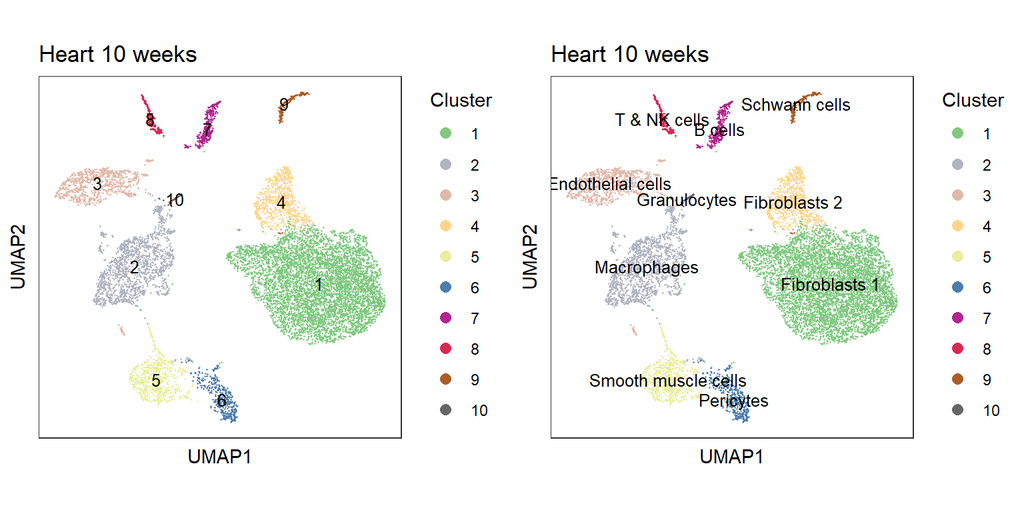

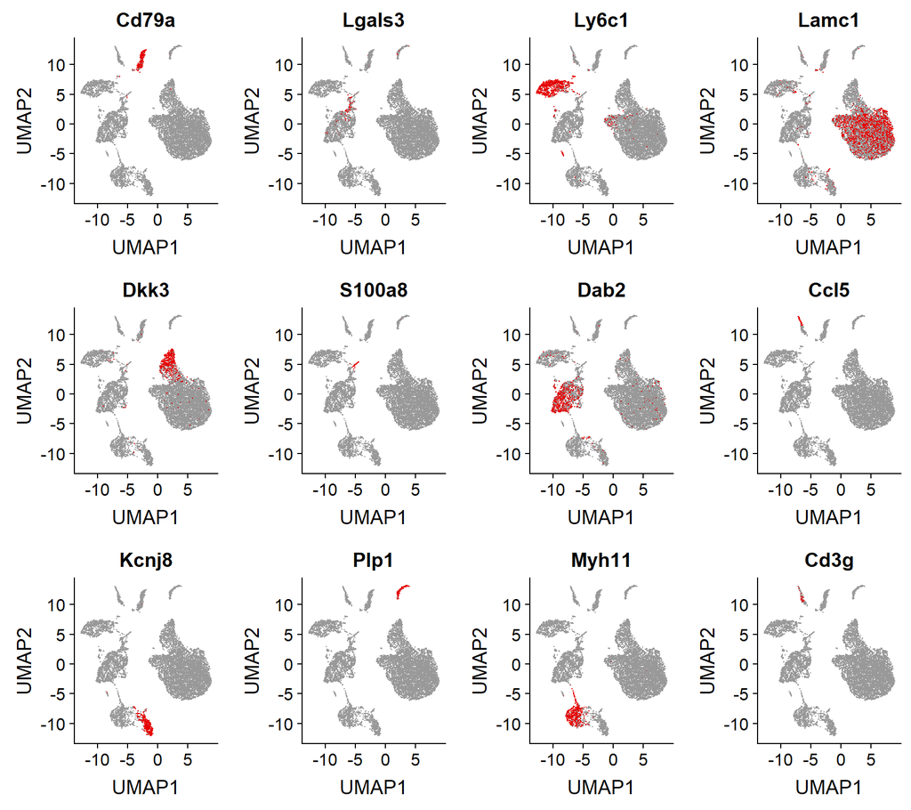

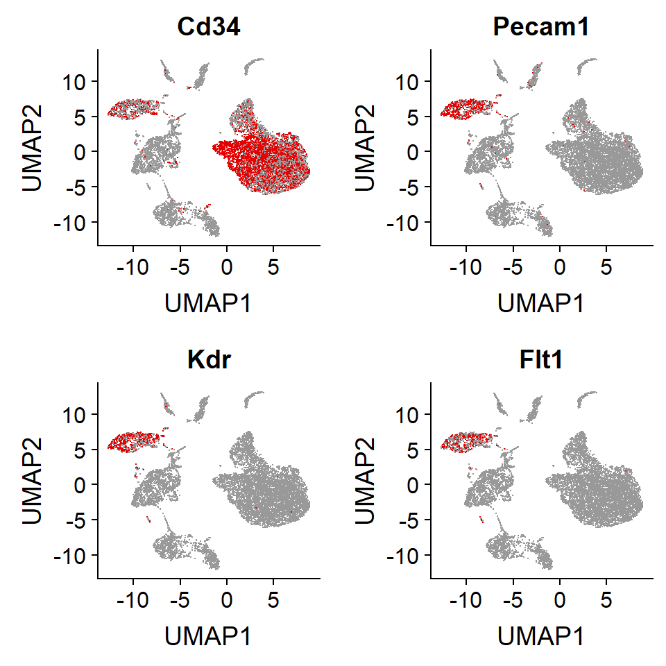

### Find markers in each group

Top 10 markers of each cluster.

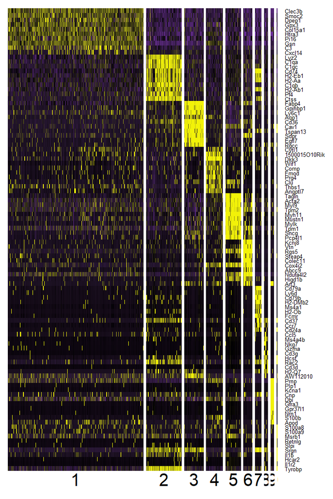

Differentially expression stats.

|  | p_val | avg_logFC | pct.1 | pct.2 | p_val_adj | cluster | gene |
| --- | --- | --- | --- | --- | --- | --- | --- |
| Clec3b | 0 | 2.07087974397775 | 0.965 | 0.472 | 0 | 1 | Clec3b |
| Smoc2 | 0 | 1.84249659273518 | 0.929 | 0.426 | 0 | 1 | Smoc2 |
| Dpep1 | 0 | 1.59141824581219 | 0.821 | 0.332 | 0 | 1 | Dpep1 |
| Gpx3 | 0 | 1.58323777297015 | 0.979 | 0.672 | 0 | 1 | Gpx3 |
| Col15a1 | 0 | 1.51642986129018 | 0.889 | 0.365 | 0 | 1 | Col15a1 |
| Htra3 | 0 | 1.48527916335653 | 0.988 | 0.672 | 0 | 1 | Htra3 |
| Pi16 | 0 | 1.47983594011404 | 0.923 | 0.769 | 0 | 1 | Pi16 |
| Gsn | 0 | 1.47094334510784 | 1 | 1 | 0 | 1 | Gsn |
| C3 | 0 | 1.46635139796538 | 0.704 | 0.377 | 0 | 1 | C3 |
| Cxcl14 | 0 | 1.46390358316873 | 0.346 | 0.176 | 0 | 1 | Cxcl14 |

[output cut: 2576 more lines]

### Enrichment

Gene Ontology

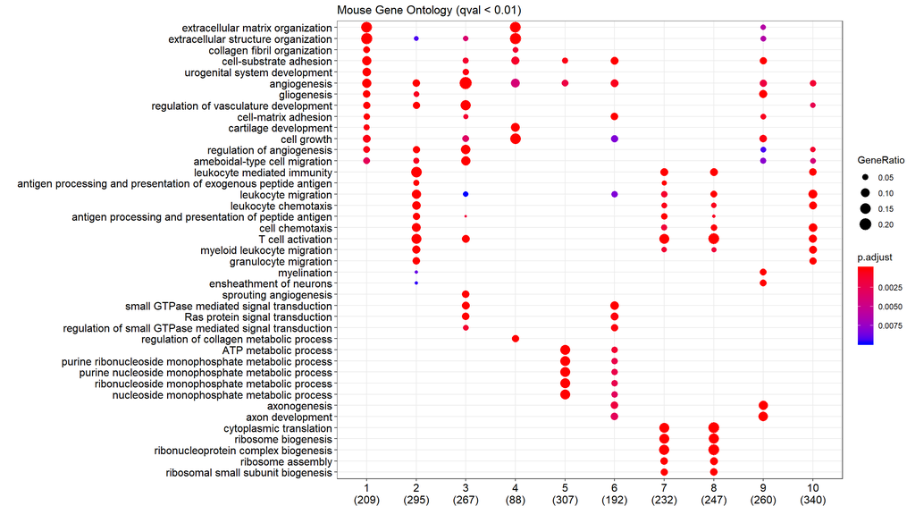

|  | Cluster | ID | Description | GeneRatio | BgRatio | pvalue | p.adjust | qvalue | geneID | Count |
| --- | --- | --- | --- | --- | --- | --- | --- | --- | --- | --- |
| 1 | 1 | GO:0030198 | extracellular matrix organization | 34/209 | 222/23843 | 2.47154230741124e-32 | 5.10051462182842e-29 | 3.77991685106097e-29 | Smoc2/Col3a1/Crispld2/Nid1/Tnxb/Lamc1/Fbln2/Pdgfra/Col1a2/Co…… | 34 |
| 2 | 1 | GO:0043062 | extracellular structure organization | 36/209 | 267/23843 | 3.60715319789846e-32 | 5.10051462182842e-29 | 3.77991685106097e-29 | Smoc2/Col3a1/Crispld2/Nid1/Tnxb/Lamc1/Fbln2/Pdgfra/Col1a2/Co…… | 36 |
| 3 | 1 | GO:0030199 | collagen fibril organization | 13/209 | 45/23843 | 7.06368750769214e-17 | 6.65870275725113e-14 | 4.93466730800528e-14 | Col3a1/Tnxb/Col1a2/Col1a1/Loxl1/Lum/Dpt/Col5a1/Serpinh1/Adamts2/Col5a2/Ddr2/Col14a1 | 13 |
| 4 | 1 | GO:0031589 | cell-substrate adhesion | 24/209 | 306/23843 | 3.78315358931039e-16 | 2.67468958764244e-13 | 1.98217336745184e-13 | Smoc2/Col3a1/Nid1/Tnxb/Lamc1/Fbln2/Col1a1/Cd34/Lamb1/Fbln1/Col8a1/Axl/Enpp2/Gpm6b/Sfrp1/Col5a3/Cd63/Ccdc80/Lgals1/Emilin1/Pdpn/Fndc3b/Itgb5/Mmp14 | 24 |
| 5 | 1 | GO:0001655 | urogenital system development | 20/209 | 333/23843 | 1.68660468295492e-11 | 8.09122966703181e-09 | 5.9962920669472e-09 | Nid1/Pdgfra/Mmp2/Gsta3/Tcf21/Fbn1/Ace/Egr1/Sfrp1/Ar/Col4a1/Nfia/Sulf1/Serpinf1/Fgfr1/Vcan/Spry1/Sulf2/Bmp4/Sox9 | 20 |
| 6 | 1 | GO:0032963 | collagen metabolic process | 12/209 | 88/23843 | 1.7166682461878e-11 | 8.09122966703181e-09 | 5.9962920669472e-09 | Tnxb/Col1a1/Mmp2/Cygb/Col5a1/Serpinh1/Mrc2/Adamts2/Mmp14/Tgfbr3/Bmp4/Ltbp1 | 12 |
| 7 | 1 | GO:0001525 | angiogenesis | 23/209 | 492/23843 | 7.57955227836342e-11 | 2.73494563292364e-08 | 2.02682824207212e-08 | C3/Dcn/Pdgfra/Mmp2/Cd34/Hspg2/Col8a1/Tcf21/Ace/Enpp2/Rhoj/Col4a1/Ecm1/Sulf1/Serpinf1/Fgfr1/Srpx2/Ptgis/Ackr3/Thbs2/Bmp4/Rora/Adm | 23 |
| 8 | 1 | GO:0030324 | lung development | 16/209 | 214/23843 | 7.73676275225924e-11 | 2.73494563292364e-08 | 2.02682824207212e-08 | Pdgfra/Meg3/Tcf21/Hsd11b1/Ace/Adamts2/Nfib/Fgfr1/Spry1/Pdpn/Heg1/Fndc3b/Mmp14/Bmp4/Sox9/Adamtsl2 | 16 |
| 9 | 1 | GO:0030323 | respiratory tube development | 16/209 | 217/23843 | 9.52446490143371e-11 | 2.99279852680606e-08 | 2.2179192536555e-08 | Pdgfra/Meg3/Tcf21/Hsd11b1/Ace/Adamts2/Nfib/Fgfr1/Spry1/Pdpn/Heg1/Fndc3b/Mmp14/Bmp4/Sox9/Adamtsl2 | 16 |
| 10 | 1 | GO:0090288 | negative regulation of cellular response to growth factor stimulus | 13/209 | 133/23843 | 1.75965184337185e-10 | 4.97629541305558e-08 | 3.68785981068773e-08 | Htra3/Dcn/Fbn1/Sfrp1/Sulf1/Nedd4/Spry1/Pmepa1/Sulf2/Tgfbr3/Htra1/Adamtsl2/Nbl1 | 13 |

[output cut: 2616 more lines]